# Проект системы диагностики эпидемиологической ситуации в странах мира

Данная система диагностики будет включать исследование имеющихся открытых статистических данных портала https://github.com/owid. Система будет предсказывать уровень заболеваемости в виде трех кластеров и прогнозировать дальнейшее развитие эпидемиологической ситуации, также отображаемое визуально.

Система имеет три кластера: зеленого цвета - страна безопасна в данный момент времени (кластер 0), въезд возможен, но не желателен (кластер 1), а также опасный уровень (кластер 2). Прогноз заболевания в выбранной стране осуществляется на 30 дней, однако данный диапазон можно изменить.

## Импорт данных

Для грамотной работы с проектом нам понадобится множество библиотек, методов и алгоритмов. Давайте начнем их импортировать. Первым делом загрузим в проект библиотеки, которые не встроены в jupyter notebook (воспользуемся методом pip install):

```python
# !pip install requests bs4 lxml
#!pip install phik
#!pip install lightgbm
```

Теперь начнем загрузку тех библиотек, методов и алгоритмов, которые встроены в jupyter notebook, а также которые мы сейчас загрузили:

```python
import pandas as pd
import requests # парсинг
from bs4 import BeautifulSoup # парсинг
import lxml # парсинг
import numpy as np
from sklearn.cluster import KMeans # кластеризация
from sklearn.mixture import GaussianMixture # кластеризация
from sklearn.preprocessing import StandardScaler # масштабирование
import matplotlib.pyplot as plt # графики
import seaborn as sns # графики
from tqdm import notebook
from sklearn.model_selection import train_test_split, KFold, RandomizedSearchCV, TimeSeriesSplit # разделение данных
from phik.report import plot_correlation_matrix # матрица зависимости данных
from sklearn.linear_model import LogisticRegression, LinearRegression # линейные модели
from sklearn.ensemble import RandomForestClassifier, RandomForestRegressor # модели ансамблей
from lightgbm import LGBMClassifier, LGBMRegressor # градиентный бустинг
from sklearn.metrics import accuracy_score, mean_squared_error # метрики
from datetime import timedelta, datetime # работа с датой

import warnings
warnings.filterwarnings('ignore')
```

Далее настроим маленькие удобства: таблица будет выводить все свои столбцы, а также все графики по умолчанию будут иметь размер 20 на 10:

```python
pd.set_option('display.max_columns', None)
sns.set(rc={'figure.figsize':(20,10)})
```

## Загрузка данных и их анализ

После того как наши основные библиотеки были загружены, можно приступить к загрузке данных с репозитория и сохранению их в переменную covid_data:

```python
path = 'https://raw.githubusercontent.com/owid/covid-19-data/master/public/data/owid-covid-data.csv'
covid_data = pd.read_csv(path, index_col=0)
```

Таблица создана, давайте проверим, какие столбцы у нас есть и что они из себя представляют:

```python
covid_data.head()
```

| iso_code | continent | location | date | total_cases | new_cases | new_cases_smoothed | total_deaths | new_deaths | new_deaths_smoothed | total_cases_per_million | new_cases_per_million | new_cases_smoothed_per_million | total_deaths_per_million | new_deaths_per_million | new_deaths_smoothed_per_million | reproduction_rate | icu_patients | icu_patients_per_million | hosp_patients | hosp_patients_per_million | weekly_icu_admissions | weekly_icu_admissions_per_million | weekly_hosp_admissions | weekly_hosp_admissions_per_million | total_tests | new_tests | total_tests_per_thousand | new_tests_per_thousand | new_tests_smoothed | … |
| --- | --- | --- | --- | --- | --- | --- | --- | --- | --- | --- | --- | --- | --- | --- | --- | --- | --- | --- | --- | --- | --- | --- | --- | --- | --- | --- | --- | --- | --- | --- |
| AFG | Asia | Afghanistan | 2020-02-24 | 5.0 | 5.0 | NaN | NaN | NaN | NaN | 0.126 | 0.126 | NaN | NaN | NaN | NaN | NaN | NaN | NaN | NaN | NaN | NaN | NaN | NaN | NaN | NaN | NaN | NaN | NaN | NaN | … |
| AFG | Asia | Afghanistan | 2020-02-25 | 5.0 | 0.0 | NaN | NaN | NaN | NaN | 0.126 | 0.000 | NaN | NaN | NaN | NaN | NaN | NaN | NaN | NaN | NaN | NaN | NaN | NaN | NaN | NaN | NaN | NaN | NaN | NaN | … |
| AFG | Asia | Afghanistan | 2020-02-26 | 5.0 | 0.0 | NaN | NaN | NaN | NaN | 0.126 | 0.000 | NaN | NaN | NaN | NaN | NaN | NaN | NaN | NaN | NaN | NaN | NaN | NaN | NaN | NaN | NaN | NaN | NaN | NaN | … |
| AFG | Asia | Afghanistan | 2020-02-27 | 5.0 | 0.0 | NaN | NaN | NaN | NaN | 0.126 | 0.000 | NaN | NaN | NaN | NaN | NaN | NaN | NaN | NaN | NaN | NaN | NaN | NaN | NaN | NaN | NaN | NaN | NaN | NaN | … |
| AFG | Asia | Afghanistan | 2020-02-28 | 5.0 | 0.0 | NaN | NaN | NaN | NaN | 0.126 | 0.000 | NaN | NaN | NaN | NaN | NaN | NaN | NaN | NaN | NaN | NaN | NaN | NaN | NaN | NaN | NaN | NaN | NaN | NaN | … |

- `iso_code` - Три буквы обозначающие страну
- `continent` - Континент географического местоположения
- `location` - Географическое местоположение
- `date` - Дата наблюдения
- `population` - Население определенной страны
- `population_density` - Площадь населения на квадратный километр
- `median_age` - Медианый возраст
- `aged_65_older` - Доля населения в возрасте 65 лет и старше
- `aged_70_older` - Доля населения в возрасте 70 лет и старше в 2015
- `gdp_per_capita` - ВВП по паритету покупательной способности
- `extreme_poverty` - Доля населения жителей, живущих в крайней нищете
- `cardiovasc_death_rate` - Смертность от сердечно-сосудистых заболеваний (смерть одного человека к 100000)
- `diabetes_prevalence` - Распространенность диабета (% процент населения возраста с 20 до 79) в 2017
- `female_smokers` - Доля курящих женщин
- `male_smokers` - Доля курящих мужчин
- `handwashing_facilities` - Доля населения с основными приспособлениями для мытья рук в помещении
- `hospital_beds_per_thousand` - Больничные койки на 1000 людей
- `life_expectancy` - Ожидаемая продолжительность жизни при рождении
- `human_development_index` - Измерение среднего объединенного индекса в трех основных измерениях человеческого развития: качество и продолжительность жизни, уровень образования и достойный уровень жизни
- `total_cases` - Всего подтвержденных случаев COVID-19
- `new_cases` - Новые подтвержденные случаи COVID-19.
- `new_cases_smoothed` - Новые подтвержденные случаи COVID-19 (сглажено за 7 дней)
- `total_deaths` - Всего смертей, связанных с COVID-19
- `new_deaths` - Новые смерти, связанные с COVID-19
- `new_deaths_smoothed` - Новые смерти, связанные с COVID-19 (сглажено за 7 дней)
- `total_cases_per_million` - Всего подтвержденных случаев COVID-19 на 1 000 000 человек
- `new_cases_per_million` - Новые подтвержденные случаи COVID-19 на 1 000 000 населения
- `new_cases_smoothed_per_million` - Новые подтвержденные случаи COVID-19 (сглажено за 7 дней) на 1 000 000 человек.
- `total_deaths_per_million` - Всего смертей от COVID-19 на 1 000 000 человек
- `new_deaths_per_million` - Новые смерти от COVID-19 на 1 000 000 человек
- `new_deaths_smoothed_per_million` - Новые смерти, связанные с COVID-19 (сглажено за 7 дней) на 1 000 000 человек
- `reproduction_rate` - Оценка эффективной скорости размножения (R) COVID-19 в режиме реального времени.
- `icu_patients` - Количество пациентов с COVID-19 в отделениях интенсивной терапии (ОИТ) в данный день
- `icu_patients_per_million` - Количество пациентов с COVID-19 в отделениях интенсивной терапии (ОИТ) в данный день на 1 000 000 человек
- `hosp_patients` - Количество пациентов с COVID-19 в больнице в данный день
- hosp_patients_per_million - Количество пациентов с COVID-19 в больнице в данный день на 1 000 000 человек
- `weekly_icu_admissions` - Количество пациентов с COVID-19, впервые поступивших в отделения интенсивной терапии (ОИТ) за данную неделю
- `weekly_icu_admissions_per_million` - Количество пациентов с COVID-19, впервые поступивших в отделения интенсивной терапии (ОИТ) за данную неделю на 1 000 000 человек
- `weekly_hosp_admissions` - Количество пациентов с COVID-19, впервые поступивших в больницы за неделю
- `weekly_hosp_admissions_per_million` - Количество пациентов с COVID-19, впервые поступивших в больницы за данную неделю, на 1 000 000 человек
- `new_tests` - Новые тесты на COVID-19 (рассчитаны только на последовательные дни)
- `total_tests` - Всего тестов на COVID-19
- `total_tests_per_thousand` - Всего тестов на COVID-19 на 1000 человек
- `new_tests_per_thousand` - Новые тесты на COVID-19 на 1000 человек
- `new_tests_smoothed` - Новые тесты на COVID-19 (7-дневные сглаженные)
- `new_tests_smoothed_per_thousand` - Новые тесты на COVID-19 (7-дневные сглаженные) на 1000 человек
- `positive_rate` - Доля положительных тестов на COVID-19, указанная как скользящее среднее за 7 дней (обратное значение test_per_case)
- `tests_per_case` - Количество тестов, проведенных на каждый новый подтвержденный случай COVID-19, представленное как скользящее среднее значение за 7 дней (обратное положительному_коэффициенту)
- `tests_units` - Единицы, используемые местоположением для сообщения данных тестирования
- `total_vaccinations` - Общее количество введенных доз вакцины против COVID-19
- `people_vaccinated` - Общее количество людей, получивших хотя бы одну дозу вакцины
- `people_fully_vaccinated` - Общее количество людей, получивших все дозы, предусмотренные первоначальным протоколом вакцинации
- `total_boosters` - Общее количество введенных бустерных доз вакцины против COVID-19 (доз, введенных сверх количества, предусмотренного протоколом вакцинации)
- `new_vaccinations` - Введены новые дозы вакцины против COVID-19 (рассчитаны только за последующие дни)
- `new_vaccinations_smoothed` - Введены новые дозы вакцины против COVID-19 (сглажено за 7 дней).
- `total_vaccinations_per_hundred` - Общее количество доз вакцины против COVID-19, введенных на 100 человек всего населения
- `people_vaccinated_per_hundred` - Общее количество людей, получивших хотя бы одну дозу вакцины на 100 человек в общей численности населения
- `people_fully_vaccinated_per_hundred` - Общее количество людей, получивших все дозы, предусмотренные протоколом первичной вакцинации, на 100 человек в общей численности населения
- `total_boosters_per_hundred` - Общее количество бустерных доз вакцины против COVID-19, введенных на 100 человек в общей численности населения
- `new_vaccinations_smoothed_per_million` - Введены новые дозы вакцины против COVID-19 (сглажено за 7 дней) на 1 000 000 человек в общей численности населения
- `new_people_vaccinated_smoothed` - Ежедневное количество людей, получивших первую дозу вакцины (сглажено за 7 дней)
- `new_people_vaccinated_smoothed_per_hundred` - Ежедневное количество людей, получающих первую дозу вакцины (сглажено за 7 дней) на 100 человек в общей численности населения
- `stringency_index` - Индекс жесткости реагирования правительства: составной показатель, основанный на 9 индикаторах реагирования, включая закрытие школ, закрытие рабочих мест и запрет на поездки, перемасштабированный до значения от 0 до 100 (100 = самый строгий ответ)
- `excess_mortality_cumulative_absolute` - Совокупная разница между зарегистрированным числом смертей с 1 января 2020 г. и прогнозируемым числом смертей за тот же период на основе предыдущих лет.
- `excess_mortality_cumulative` - Процентная разница между совокупным числом смертей с 1 января 2020 г. и совокупным прогнозируемым числом смертей за тот же период на основе предыдущих лет.
- `excess_mortality` - Процентная разница между зарегистрированным количеством еженедельных или ежемесячных смертей в 2020–2021 гг. и прогнозируемым количеством смертей за тот же период на основе предыдущих лет
- `excess_mortality_cumulative_per_million` - Совокупная разница между зарегистрированным числом смертей с 1 января 2020 года и прогнозируемым числом смертей за тот же период на основе предыдущих лет на миллион человек.

Описав все столбцы в таблице нужно перейти к краткой информации о данных:

```python
covid_data.info()
```

```
<class 'pandas.core.frame.DataFrame'>
Index: 173258 entries, AFG to ZWE
Data columns (total 66 columns):
 #   Column                                      Non-Null Count   Dtype
---  ------                                      --------------   -----
 0   continent                                   162964 non-null  object
 1   location                                    173258 non-null  object
 2   date                                        173258 non-null  object
 3   total_cases                                 169221 non-null  float64
 4   new_cases                                   169065 non-null  float64
 5   new_cases_smoothed                          167072 non-null  float64
 6   total_deaths                                151165 non-null  float64
 7   new_deaths                                  151189 non-null  float64
 8   new_deaths_smoothed                         149037 non-null  float64
 9   total_cases_per_million                     168437 non-null  float64
```

[output cut: 58 more lines]

Всего у нас 170 тысяч строк, из которых максимальное число пропусков до ходит до 163 тысяч строк. Формат столбцов у всех верный, кроме `date` - необходимо заменить на datetime. Так как данных у нас много, стоит выделить те, что нам нужны для предсказания уровня опасности страны, а также предсказания заражения наперед. Стоит рассмотреть следующие столбцы:

- location - обязателен, ведь нужно знать в какой стране мы будем предсказывать данные
- date - все строится по дате, это наш ключевой столбец
- population_density - площадь населения может пригодится при предсказании новых случаев заражения
- reproduction_rate - скорости размножения короновирусной инфекции также может понадобится при предсказании уровня опасности и новых случаев заражения
- hosp_patients - количество пациентов также может показать сильную связь с новыми заражениями, ведь чем больше пациентов, тем больше зараженных
- new_tests - новые тесты показывают, как много зараженных становится изо дня в день
- total_vaccinations - общее количество вакцинированных поможет заметить связь с число зараженных (чем больше прививок, тем меньше зараженных)
- people_fully_vaccinated_per_hundred - количество вакцинированных на 100 человек покажет нам частоту вакцинации населения, что может помочь в предсказании новых случаев заражения
- total_deaths - чем больше смертей, тем больше зараженных
- new_deaths - чем больше смертей, тем больше зараженных
- total_cases - сумма того, что нам нужно предсказать
- new_cases - целевая переменная

```python
important_col = ['location', 'date', 'population_density', 'reproduction_rate', 'hosp_patients',
                'new_tests', 'people_fully_vaccinated_per_hundred', 'new_deaths', 'new_cases']
important_data = covid_data.reset_index()[important_col]
important_data.head()
```

|  | location | date | population_density | reproduction_rate | hosp_patients | new_tests | people_fully_vaccinated_per_hundred | new_deaths | new_cases |
| --- | --- | --- | --- | --- | --- | --- | --- | --- | --- |
| 0 | Afghanistan | 2020-02-24 | 54.422 | NaN | NaN | NaN | NaN | NaN | 5.0 |
| 1 | Afghanistan | 2020-02-25 | 54.422 | NaN | NaN | NaN | NaN | NaN | 0.0 |
| 2 | Afghanistan | 2020-02-26 | 54.422 | NaN | NaN | NaN | NaN | NaN | 0.0 |
| 3 | Afghanistan | 2020-02-27 | 54.422 | NaN | NaN | NaN | NaN | NaN | 0.0 |
| 4 | Afghanistan | 2020-02-28 | 54.422 | NaN | NaN | NaN | NaN | NaN | 0.0 |

Необходимые столбцы были выбраны и теперь наша таблица стала более удобной в чтении и анализе. Давайте проверим, все-ли значения в столбце `location` верны и нет ли там ненужных данных:

```python
covid_data['location'].unique()
```

```
array(['Afghanistan', 'Africa', 'Albania', 'Algeria', 'Andorra', 'Angola',
       'Anguilla', 'Antigua and Barbuda', 'Argentina', 'Armenia', 'Aruba',
       'Asia', 'Australia', 'Austria', 'Azerbaijan', 'Bahamas', 'Bahrain',
       'Bangladesh', 'Barbados', 'Belarus', 'Belgium', 'Belize', 'Benin',
       'Bermuda', 'Bhutan', 'Bolivia', 'Bonaire Sint Eustatius and Saba',
       'Bosnia and Herzegovina', 'Botswana', 'Brazil',
       'British Virgin Islands', 'Brunei', 'Bulgaria', 'Burkina Faso',
       'Burundi', 'Cambodia', 'Cameroon', 'Canada', 'Cape Verde',
       'Cayman Islands', 'Central African Republic', 'Chad', 'Chile',
       'China', 'Colombia', 'Comoros', 'Congo', 'Cook Islands',
       'Costa Rica', "Cote d'Ivoire", 'Croatia', 'Cuba', 'Curacao',
       'Cyprus', 'Czechia', 'Democratic Republic of Congo', 'Denmark',
       'Djibouti', 'Dominica', 'Dominican Republic', 'Ecuador', 'Egypt',
       'El Salvador', 'Equatorial Guinea', 'Eritrea', 'Estonia',
       'Eswatini', 'Ethiopia', 'Europe', 'European Union',
       'Faeroe Islands', 'Falkland Islands', 'Fiji', 'Finland', 'France',
       'French Polynesia', 'Gabon', 'Gambia', 'Georgia', 'Germany',
       'Ghana', 'Gibraltar', 'Greece', 'Greenland', 'Grenada',
       'Guatemala', 'Guernsey', 'Guinea', 'Guinea-Bissau', 'Guyana',
       'Haiti', 'High income', 'Honduras', 'Hong Kong', 'Hungary',
       'Iceland', 'India', 'Indonesia', 'International', 'Iran', 'Iraq',
       'Ireland', 'Isle of Man', 'Israel', 'Italy', 'Jamaica', 'Japan',
       'Jersey', 'Jordan', 'Kazakhstan', 'Kenya', 'Kiribati', 'Kosovo',
       'Kuwait', 'Kyrgyzstan', 'Laos', 'Latvia', 'Lebanon', 'Lesotho',
       'Liberia', 'Libya', 'Liechtenstein', 'Lithuania', 'Low income',
       'Lower middle income', 'Luxembourg', 'Macao', 'Madagascar',
       'Malawi', 'Malaysia', 'Maldives', 'Mali', 'Malta',
       'Marshall Islands', 'Mauritania', 'Mauritius', 'Mexico',
       'Micronesia (country)', 'Moldova', 'Monaco', 'Mongolia',
       'Montenegro', 'Montserrat', 'Morocco', 'Mozambique', 'Myanmar',
       'Namibia', 'Nauru', 'Nepal', 'Netherlands', 'New Caledonia',
       'New Zealand', 'Nicaragua', 'Niger', 'Nigeria', 'Niue',
       'North America', 'North Macedonia', 'Northern Cyprus', 'Norway',
       'Oceania', 'Oman', 'Pakistan', 'Palau', 'Palestine', 'Panama',
       'Papua New Guinea', 'Paraguay', 'Peru', 'Philippines', 'Pitcairn',
       'Poland', 'Portugal', 'Puerto Rico', 'Qatar', 'Romania', 'Russia',
       'Rwanda', 'Saint Helena', 'Saint Kitts and Nevis', 'Saint Lucia',
       'Saint Pierre and Miquelon', 'Saint Vincent and the Grenadines',
       'Samoa', 'San Marino', 'Sao Tome and Principe', 'Saudi Arabia',
       'Senegal', 'Serbia', 'Seychelles', 'Sierra Leone', 'Singapore',
       'Sint Maarten (Dutch part)', 'Slovakia', 'Slovenia',
       'Solomon Islands', 'Somalia', 'South Africa', 'South America',
       'South Korea', 'South Sudan', 'Spain', 'Sri Lanka', 'Sudan',
       'Suriname', 'Sweden', 'Switzerland', 'Syria', 'Taiwan',
       'Tajikistan', 'Tanzania', 'Thailand', 'Timor', 'Togo', 'Tokelau',
       'Tonga', 'Trinidad and Tobago', 'Tunisia', 'Turkey',
       'Turkmenistan', 'Turks and Caicos Islands', 'Tuvalu', 'Uganda',
       'Ukraine', 'United Arab Emirates', 'United Kingdom',
       'United States', 'Upper middle income', 'Uruguay', 'Uzbekistan',
       'Vanuatu', 'Vatican', 'Venezuela', 'Vietnam', 'Wallis and Futuna',
       'World', 'Yemen', 'Zambia', 'Zimbabwe'], dtype=object)
```

Как можно заметить, в столбце `location` есть неверные значения и их не мало: Africa, Asia ... Теперь нужно проверить, сколько пропусков присутствует в наших столбцах. Для этого создадим графическую таблицу:

```python
passed_data = important_data.isna().sum().reset_index()
passed_data.columns = ['column', 'count_passed']
passed_data = passed_data.sort_values('count_passed', ascending=False)
passed_data['percent_of_passed'] = passed_data['count_passed']/important_data.shape[0]
```

```python
passed_data.style.bar(subset=['count_passed','percent_of_passed'], color='#d65f5f')
```

|  | column | count_passed | percent_of_passed |
| --- | --- | --- | --- |
| 4 | hosp_patients | 148316 | 0.856041 |
| 6 | people_fully_vaccinated_per_hundred | 130685 | 0.754280 |
| 5 | new_tests | 104230 | 0.601588 |
| 3 | reproduction_rate | 43071 | 0.248595 |
| 7 | new_deaths | 22069 | 0.127377 |
| 2 | population_density | 19175 | 0.110673 |
| 8 | new_cases | 4193 | 0.024201 |
| 0 | location | 0 | 0.000000 |
| 1 | date | 0 | 0.000000 |

## Предобработка данных

На данном этапе мы будем решать проблему пропусков, неверных значений, а также поиском аномалий в данных.

Неверные значения нужно посмотреть в столбце `location`, где можно было заметить "не страны": Africa, Europe и т д.

У нас много ошибочных значений в столбце `location`, к примеру Aftica, Asia не являются странами, поэтому их стоит убрать отсюда:

```python
print('До удаления ненужных локаций:', covid_data.shape)
wrong_location = (['Africa', 'Asia', 'Europe', 'European Union', 'High income',
                   'International', 'Low income', 'Lower middle income',
                   'North America','South America', 'Oceania', 'Upper middle income',
                   'World'])
covid_data = covid_data.query("location not in @wrong_location")
print('После удаления ненужных локаций:', covid_data.shape)
```

```
До удаления ненужных локаций: (173258, 66)
После удаления ненужных локаций: (162964, 66)
```

Мы удалили 10 тысяч строк, что не так много и это никак не сказалось на логике данных. Теперь нужно заполнить пустые значения. Выделим два списка: первый - col_fill_values, где мы будем заполнять 0 те места, где у нас вообще нет никаких значений и значением предыдущей строки, если пустое значение находится между данными, которые имеют значения. Второй список - заполнение каким-нибудь заполнителем, например -1:

```python
col_fill_values = ['hosp_patients', 'people_fully_vaccinated_per_hundred', 'new_tests',
                   'reproduction_rate', 'new_deaths', 'new_cases',]
col_fill_undefined = ['population_density']
```

```python
for col in notebook.tqdm(col_fill_values):
    for index in notebook.tqdm(range(important_data.shape[0])):
        try:
            if important_data.loc[index].isna()[col] == True:
                new_value = important_data.copy().loc[index-1, col]
                important_data.loc[index, col] = new_value
        except:
            important_data.loc[index, col] = 0
```

```python
important_data.head(30)
```

|  | location | date | population_density | reproduction_rate | hosp_patients | new_tests | people_fully_vaccinated_per_hundred | new_deaths | new_cases |
| --- | --- | --- | --- | --- | --- | --- | --- | --- | --- |
| 0 | Afghanistan | 2020-02-24 | 54.422 | 0.0 | 0.0 | 0.0 | 0.0 | 0.0 | 5.0 |
| 1 | Afghanistan | 2020-02-25 | 54.422 | 0.0 | 0.0 | 0.0 | 0.0 | 0.0 | 0.0 |
| 2 | Afghanistan | 2020-02-26 | 54.422 | 0.0 | 0.0 | 0.0 | 0.0 | 0.0 | 0.0 |
| 3 | Afghanistan | 2020-02-27 | 54.422 | 0.0 | 0.0 | 0.0 | 0.0 | 0.0 | 0.0 |
| 4 | Afghanistan | 2020-02-28 | 54.422 | 0.0 | 0.0 | 0.0 | 0.0 | 0.0 | 0.0 |
| 5 | Afghanistan | 2020-02-29 | 54.422 | 0.0 | 0.0 | 0.0 | 0.0 | 0.0 | 0.0 |
| 6 | Afghanistan | 2020-03-01 | 54.422 | 0.0 | 0.0 | 0.0 | 0.0 | 0.0 | 0.0 |
| 7 | Afghanistan | 2020-03-02 | 54.422 | 0.0 | 0.0 | 0.0 | 0.0 | 0.0 | 0.0 |
| 8 | Afghanistan | 2020-03-03 | 54.422 | 0.0 | 0.0 | 0.0 | 0.0 | 0.0 | 0.0 |
| 9 | Afghanistan | 2020-03-04 | 54.422 | 0.0 | 0.0 | 0.0 | 0.0 | 0.0 | 0.0 |
| 10 | Afghanistan | 2020-03-05 | 54.422 | 0.0 | 0.0 | 0.0 | 0.0 | 0.0 | 0.0 |
| 11 | Afghanistan | 2020-03-06 | 54.422 | 0.0 | 0.0 | 0.0 | 0.0 | 0.0 | 0.0 |
| 12 | Afghanistan | 2020-03-07 | 54.422 | 0.0 | 0.0 | 0.0 | 0.0 | 0.0 | 3.0 |
| 13 | Afghanistan | 2020-03-08 | 54.422 | 0.0 | 0.0 | 0.0 | 0.0 | 0.0 | 0.0 |
| 14 | Afghanistan | 2020-03-09 | 54.422 | 0.0 | 0.0 | 0.0 | 0.0 | 0.0 | 0.0 |
| 15 | Afghanistan | 2020-03-10 | 54.422 | 0.0 | 0.0 | 0.0 | 0.0 | 0.0 | 0.0 |
| 16 | Afghanistan | 2020-03-11 | 54.422 | 0.0 | 0.0 | 0.0 | 0.0 | 0.0 | 3.0 |
| 17 | Afghanistan | 2020-03-12 | 54.422 | 0.0 | 0.0 | 0.0 | 0.0 | 0.0 | 0.0 |
| 18 | Afghanistan | 2020-03-13 | 54.422 | 0.0 | 0.0 | 0.0 | 0.0 | 0.0 | 0.0 |
| 19 | Afghanistan | 2020-03-14 | 54.422 | 0.0 | 0.0 | 0.0 | 0.0 | 0.0 | 3.0 |
| 20 | Afghanistan | 2020-03-15 | 54.422 | 0.0 | 0.0 | 0.0 | 0.0 | 0.0 | 6.0 |
| 21 | Afghanistan | 2020-03-16 | 54.422 | 0.0 | 0.0 | 0.0 | 0.0 | 0.0 | 5.0 |
| 22 | Afghanistan | 2020-03-17 | 54.422 | 0.0 | 0.0 | 0.0 | 0.0 | 0.0 | 1.0 |
| 23 | Afghanistan | 2020-03-18 | 54.422 | 0.0 | 0.0 | 0.0 | 0.0 | 0.0 | 0.0 |
| 24 | Afghanistan | 2020-03-19 | 54.422 | 0.0 | 0.0 | 0.0 | 0.0 | 0.0 | 0.0 |
| 25 | Afghanistan | 2020-03-20 | 54.422 | 0.0 | 0.0 | 0.0 | 0.0 | 0.0 | 0.0 |
| 26 | Afghanistan | 2020-03-21 | 54.422 | 0.0 | 0.0 | 0.0 | 0.0 | 0.0 | 0.0 |
| 27 | Afghanistan | 2020-03-22 | 54.422 | 0.0 | 0.0 | 0.0 | 0.0 | 0.0 | 10.0 |
| 28 | Afghanistan | 2020-03-23 | 54.422 | 0.0 | 0.0 | 0.0 | 0.0 | 1.0 | 6.0 |
| 29 | Afghanistan | 2020-03-24 | 54.422 | 0.0 | 0.0 | 0.0 | 0.0 | 0.0 | 2.0 |

```python
important_data['population_density'] = important_data['population_density'].fillna(-1)
```

Заполнение пустых значений завершено, теперь наши данные осталось проверить на аномалии и изменить формат столбца `date` на date:

```python
important_data['date'] = pd.to_datetime(important_data['date'], format='%Y-%m-%d')
```

```python
important_data.info()
```

```
<class 'pandas.core.frame.DataFrame'>
RangeIndex: 173258 entries, 0 to 173257
Data columns (total 9 columns):
 #   Column                               Non-Null Count   Dtype
---  ------                               --------------   -----
 0   location                             173258 non-null  object
 1   date                                 173258 non-null  datetime64[ns]
 2   population_density                   173258 non-null  float64
 3   reproduction_rate                    173258 non-null  float64
 4   hosp_patients                        173258 non-null  float64
 5   new_tests                            173258 non-null  float64
 6   people_fully_vaccinated_per_hundred  173258 non-null  float64
 7   new_deaths                           173258 non-null  float64
 8   new_cases                            173258 non-null  float64
dtypes: datetime64[ns](1), float64(7), object(1)
memory usage: 11.9+ MB
```

Как видно по верхней таблице, формат столбца `date` изменен на `datetime64`, что нам и нужно было. Пропуски отсутствуют, значит нам осталось проверить последний момент - наличие аномальных значений в таблице:

```python
important_data.describe()
```

|  | population_density | reproduction_rate | hosp_patients | new_tests | people_fully_vaccinated_per_hundred | new_deaths | new_cases |
| --- | --- | --- | --- | --- | --- | --- | --- |
| count | 173258.000000 | 173258.000000 | 173258.000000 | 1.732580e+05 | 173258.000000 | 173258.000000 | 1.732580e+05 |
| mean | 412.071508 | 0.955066 | 4545.909459 | 5.410379e+04 | 42.051735 | 155.004796 | 1.237636e+04 |
| std | 2020.248907 | 0.367213 | 7552.785915 | 1.653021e+05 | 28.998123 | 775.582063 | 8.738425e+04 |
| min | -1.000000 | -0.040000 | 0.000000 | 0.000000e+00 | 0.000000 | 0.000000 | 0.000000e+00 |
| 25% | 19.751000 | 0.750000 | 337.000000 | 1.795000e+03 | 13.700000 | 0.000000 | 1.000000e+00 |
| 50% | 76.399000 | 0.960000 | 1787.000000 | 6.384000e+03 | 45.545000 | 1.000000 | 8.200000e+01 |
| 75% | 205.859000 | 1.150000 | 4225.000000 | 2.403900e+04 | 67.080000 | 19.000000 | 1.160000e+03 |
| max | 20546.766000 | 6.140000 | 154540.000000 | 3.740296e+06 | 122.540000 | 18156.000000 | 4.089078e+06 |

По таблице выше заметно, что в столбце `population_density` минимальное значение = -1, что верно, ведь мы выше все пропуски заменяли на данное значение. Столбец `reprodiction_rate` содержит минмиальное значение -0.04, что опять же логично, ведь скорость заражение COVID может стать отрицательной, благодаря вакцинации населения.

В итоге в данных все отлично.

Предобработка данных завершена и можно приступить к этапу создания нового признака - rt_value (коэффициент распространения инфекции)

## Создание нового признака

На данном этапе будет создан новый признак - коэффициент распространения инфекции (Rt). Для того, чтобы понять что это за коэффициент, необходимо привести формулу подсчета данного коэффициента:

Для реализации данной формулы мы применим работу двух циклов, которые будут пробегать по всем странам в таблице и по всей таблице, которая была сгруппирована по стране и датам. Если дней с начала ведения записей прошло меньше 8, то rt равен 0. Если в знаменателе получается 0, то rt равен 0. Результаты rt значений мы записываем в список, который в дальнейшем используем:

```python
rt_values = []
pivot_table = important_data.groupby(['location', 'date'])['new_cases'].sum()
all_countries = list(important_data['location'].unique())
for country in notebook.tqdm(all_countries):
    for days_observation in range(1, pivot_table[country].count()+1):
        if days_observation >= 8:
            rt_value_denominator = sum(pivot_table[country][days_observation-4:days_observation-1])
            rt_value_numerator = sum(pivot_table[country][days_observation-8:days_observation-5])
            try:
                rt_values.append(rt_value_numerator/rt_value_denominator)
            except:
                rt_values.append(0.0)
        else:
            rt_values.append(0.0)
```

Отлично, все значения записаны в список и мы можем их применить - для этого создаем новый столбец `rt_value` и вносим в него значения со списка:

```python
important_data['rt_value'] = rt_values.copy()
important_data['rt_value'] = round(important_data['rt_value'], 4)
important_data.tail()
```

|  | location | date | population_density | reproduction_rate | hosp_patients | new_tests | people_fully_vaccinated_per_hundred | new_deaths | new_cases | rt_value |
| --- | --- | --- | --- | --- | --- | --- | --- | --- | --- | --- |
| 173253 | Zimbabwe | 2022-03-27 | 42.729 | 0.83 | 11583.0 | 4859.0 | 23.15 | 2.0 | 175.0 | 0.3392 |
| 173254 | Zimbabwe | 2022-03-28 | 42.729 | 0.83 | 11583.0 | 4859.0 | 23.20 | 0.0 | 107.0 | 0.8083 |
| 173255 | Zimbabwe | 2022-03-29 | 42.729 | 0.83 | 11583.0 | 4859.0 | 23.26 | 1.0 | 115.0 | 1.8050 |
| 173256 | Zimbabwe | 2022-03-30 | 42.729 | 0.83 | 11583.0 | 4859.0 | 23.34 | 1.0 | 140.0 | 2.4181 |
| 173257 | Zimbabwe | 2022-03-31 | 42.729 | 0.83 | 11583.0 | 4859.0 | 23.41 | 4.0 | 104.0 | 1.8978 |

Значения добавлены, однако давайте проверим их на адекватность:

```python
important_data.rt_value.describe()
```

```
count    173258.00000
mean          3.40814
std         768.21109
min           0.00000
25%           0.44440
50%           0.89140
75%           1.20080
max      317562.00000
Name: rt_value, dtype: float64
```

Максимальное значение столбца получается довольно большим, а это значит, что данный выброс нужно отбросить (некоторые модели машинного обучения крайне чувствительны к выбросам). Для этого выберим крайнее значение, после которого мы будем отбрасывать данные:

```python
important_data[important_data.rt_value > 2.5]['rt_value'].count()/important_data.shape[0]
```

```
0.04278590310404137
```

В процессе отбора значения выяснилось, что значение 2.5 может послужить границей отделения. Обрезаем данные по данное значение включительно, а то, что будет больше граничного значения, то брать в таблицу не будем:

```python
cutted_data = important_data[important_data.rt_value <= 2.5]
cutted_data.shape[0]
```

```
165845
```

Создание нового признака завершено, также было проведено отбрасывания аномальных значений. Далее мы приступаем к кластеризации.

## Кластеризация

Задача кластеризации – определить уровни опасности для туристов и дать им наименования. В результате кластеризации может получиться несколько уровней опасности для одной страны в разные периоды времени.

Для кластеризации были выбраны две модели: Kmeans (за счет своей простоты и скорости) и GaussianMixture (за счет скорости и качества лучше, чем у Kmeans).

Для кластеризации мы решили взяли все признаки из таблицы `cutted_data` и создали на ее основе две таблицы для работы с разными кластерами: `data_for_clusters_km` и `data_for_clusters_gm`:

```python
data_for_clusters = cutted_data.copy()
data_for_clusters_km = data_for_clusters.copy()
data_for_clusters_gm = data_for_clusters.copy()
```

Первый алгоритм кластеризации - Kmeans. Его мы обучим на всех данных, кроме `location` и `date`:

```python
model = KMeans(n_clusters=3, max_iter=300, n_init=10, random_state=49)
data_for_clusters_km['clusters'] = model.fit_predict(data_for_clusters_km.drop(['location', 'date'], axis=1))
data_for_clusters_km.clusters.value_counts()
```

```
0    153016
1     11537
2      1292
Name: clusters, dtype: int64
```

На выходе получаем картину, в которой почти все данные принадлежат кластеру 0. Давайте посмотрим какие максимальные новые случаи были в данных кластерах:

```python
print("Максимальный коэффициент распространения инфекции в кластере 0:", data_for_clusters_km[data_for_clusters_km.clusters == 0]['new_cases'].max())
print("Максимальный коэффициент распространения инфекции в кластере 1:", data_for_clusters_km[data_for_clusters_km.clusters == 1]['new_cases'].max())
print("Максимальный коэффициент распространения инфекции в кластере 2:", data_for_clusters_km[data_for_clusters_km.clusters == 2]['new_cases'].max())
```

```
Максимальный коэффициент распространения инфекции в кластере 0: 1140035.0
Максимальный коэффициент распространения инфекции в кластере 1: 4089078.0
Максимальный коэффициент распространения инфекции в кластере 2: 1382163.0
```

```python
colors = ['lightgreen', 'orange', 'red']
data_for_clusters_km['color'] = data_for_clusters_km.clusters.map({0:colors[0], 1:colors[2], 2:colors[1]})
```

Теперь можем визуализировать данные:

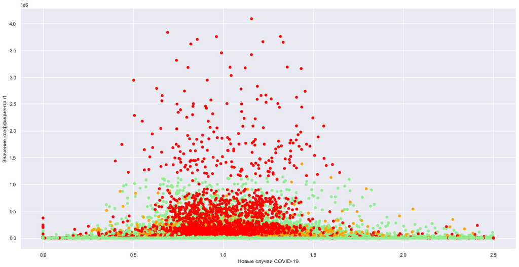

```python
plt.scatter(data_for_clusters_km.rt_value, data_for_clusters_km.new_cases, c=data_for_clusters_km.color, s=30)
#plt.ylim(-0.1, 30)
#plt.xlim(-1, 60)
plt.xlabel('Новые случаи COVID-19')
plt.ylabel('Значение коэффициента rt')
```

По графику видно, что опасный уровень страны хоть и выделяется, но только в самые тяжелые случаи, в центре данные смешиваются и непонятно, где опасно, а где безопасно. Необходимо рассмотреть другой алгоритм кластеризации - GaussianMixture.

```python
gm = GaussianMixture(n_components=3, random_state=49)

data_for_clusters_gm['clusters'] = gm.fit_predict(data_for_clusters_gm.drop(['location', 'date'], axis=1))
data_for_clusters_gm['clusters'].value_counts()
```

```
1    73557
0    64772
2    27516
Name: clusters, dtype: int64
```

```python
print("Максимальный коэффициент распространения инфекции в кластере 0:", data_for_clusters_gm[data_for_clusters_gm.clusters == 0]['new_cases'].max())
print("Максимальный коэффициент распространения инфекции в кластере 1:", data_for_clusters_gm[data_for_clusters_gm.clusters == 1]['new_cases'].max())
print("Максимальный коэффициент распространения инфекции в кластере 2:", data_for_clusters_gm[data_for_clusters_gm.clusters == 2]['new_cases'].max())
```

```
Максимальный коэффициент распространения инфекции в кластере 0: 520.0
Максимальный коэффициент распространения инфекции в кластере 1: 76991.0
Максимальный коэффициент распространения инфекции в кластере 2: 4089078.0
```

```python
data_for_clusters_gm['color'] = data_for_clusters_gm.clusters.map({0:colors[0], 1:colors[1], 2:colors[2]})
```

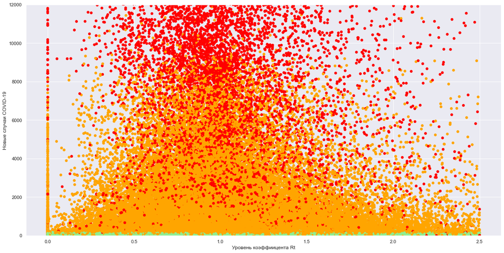

```python
plt.scatter(data_for_clusters_gm.rt_value, data_for_clusters_gm.new_cases, c=data_for_clusters_gm.color, s=30)
plt.ylim(-10, 12000)
plt.xlabel('Уровень коэффиицента Rt')
plt.ylabel('Новые случаи COVID-19')
```

По графику видно, что высокий уровень опасности хорошо отделяется от среднего уровня и тем более от безопасного, однако может заметить присутствие красных точек в гуще оранжевых - это может говорить о том, что в данных странах все совсем плохо, если такое количество новых случаев в день заставляет их соотносить к опасным странам.

В качестве основного алгоритма мы выбрали Gaussian, его кластеры и цвета мы добавим в нашу основную таблицу:

```python
data_for_clusters_gm.columns
```

```
Index(['location', 'date', 'population_density', 'reproduction_rate',
       'hosp_patients', 'new_tests', 'people_fully_vaccinated_per_hundred',
       'new_deaths', 'new_cases', 'rt_value', 'clusters', 'color'],
      dtype='object')
```

```python
data_ready = cutted_data.merge(data_for_clusters_gm, on=['location', 'date', 'population_density', 'reproduction_rate',
       'hosp_patients', 'new_tests', 'people_fully_vaccinated_per_hundred',
       'new_deaths', 'new_cases', 'rt_value'])
data_ready.head()
```

|  | location | date | population_density | reproduction_rate | hosp_patients | new_tests | people_fully_vaccinated_per_hundred | new_deaths | new_cases | rt_value | clusters | color |
| --- | --- | --- | --- | --- | --- | --- | --- | --- | --- | --- | --- | --- |
| 0 | Afghanistan | 2020-02-24 | 54.422 | 0.0 | 0.0 | 0.0 | 0.0 | 0.0 | 5.0 | 0.0 | 0 | lightgreen |
| 1 | Afghanistan | 2020-02-25 | 54.422 | 0.0 | 0.0 | 0.0 | 0.0 | 0.0 | 0.0 | 0.0 | 0 | lightgreen |
| 2 | Afghanistan | 2020-02-26 | 54.422 | 0.0 | 0.0 | 0.0 | 0.0 | 0.0 | 0.0 | 0.0 | 0 | lightgreen |
| 3 | Afghanistan | 2020-02-27 | 54.422 | 0.0 | 0.0 | 0.0 | 0.0 | 0.0 | 0.0 | 0.0 | 0 | lightgreen |
| 4 | Afghanistan | 2020-02-28 | 54.422 | 0.0 | 0.0 | 0.0 | 0.0 | 0.0 | 0.0 | 0.0 | 0 | lightgreen |

Таблица готова, однако стоит изменить значения кластеров либо сделать отдельный столбец с текстовым описанием кластеров - так будет понятнее и легче определить, какой промежуток времени можно считать опасным, не самым лучшим или безопасным:

```python
data_ready['cluster_info'] = data_ready['clusters'].replace([0, 1, 2], ['безопасно', 'не советуем', 'опасно'])
```

Этап кластеризации завершен, теперь можно приступить к поиску наиболее важных признаков для предсказания уровня опасности страны в определенный промежуток времени.

## Поиск наиболее зависимых признаков

На данном этапе будет проведен поиск наиболее зависимых признаков к столбцу `clusters`. Зависимость будем проверять с помощью корреляции Пирсона и коэффициента корреляции, основанного на нескольких уточнениях проверки гипотезы Пирсона. В результате мы найдем наиболее зависимые признаки, которые и возьмем на обучение моделей.

Первым делом стоит привести столбец `date` в разряд индексов, так нам станет легче работать при проверке дат, а также прогноза новых случаев заражения:

```python
data_ready = data_ready.set_index('date')
data_ready.sort_index(inplace=True)
data_ready.head()
```

| date | location | population_density | reproduction_rate | hosp_patients | new_tests | people_fully_vaccinated_per_hundred | new_deaths | new_cases | rt_value | clusters | color | cluster_info |
| --- | --- | --- | --- | --- | --- | --- | --- | --- | --- | --- | --- | --- |
| 2020-01-01 | Argentina | 16.177 | 0.37 | 0.0 | 4.0 | 62.34 | 0.0 | 0.0 | 0.0 | 0 | lightgreen | безопасно |
| 2020-01-01 | Mexico | 66.444 | 0.12 | 77.0 | 25.0 | 75.66 | 0.0 | 6143.0 | 0.0 | 1 | orange | не советуем |
| 2020-01-02 | Argentina | 16.177 | 0.37 | 0.0 | 95.0 | 62.34 | 0.0 | 0.0 | 0.0 | 0 | lightgreen | безопасно |
| 2020-01-02 | Mexico | 66.444 | 0.12 | 77.0 | 72.0 | 75.66 | 0.0 | 6143.0 | 0.0 | 1 | orange | не советуем |
| 2020-01-03 | Mexico | 66.444 | 0.12 | 77.0 | 89.0 | 75.66 | 0.0 | 6143.0 | 0.0 | 1 | orange | не советуем |

Первый алгоритм корреляции - корреляция Пирсона. В качестве данных, которые мы будем проверять, будут все признаки не текстового формата, ведь алгоритм не может работать с текстовой информацией:

```python
corr_data = data_ready[list(data_ready.columns[1:-2])]
```

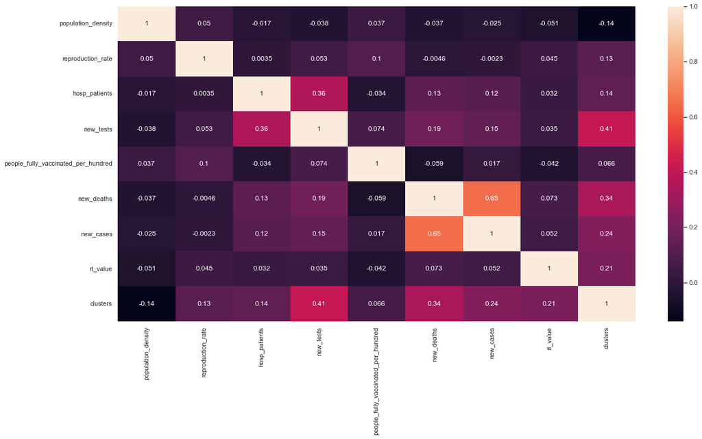

```python
sns.heatmap(corr_data.corr(), annot=True)
```

По корреляции Пирсона заметно, что признаки `new_tests`, `new_deaths`, `new_cases`, `rt_value` имеют зависимость в 20-42%, что и можно считать допустимой нормой.

Следующий алгоритм - обновленная корреляция Пирсона - `phik matrix`. Для этого алгоритма мы должны указать интервальные столбцы (все наши столбцы можно считать интервальными):

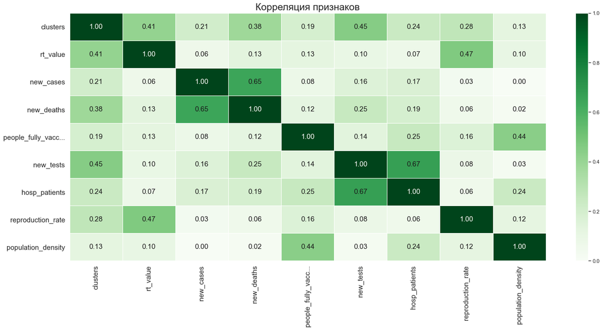

```python
interval_cols = ['population_density', 'reproduction_rate', 'hosp_patients','new_tests',
                 'people_fully_vaccinated_per_hundred', 'new_deaths',
                 'new_cases', 'rt_value']
phik_overview = corr_data.phik_matrix(interval_cols=interval_cols)

plot_correlation_matrix(phik_overview.values,
                        x_labels=phik_overview.columns,
                        y_labels=phik_overview.index,
                        vmin=0, vmax=1, color_map="Greens",
                        title="Корреляция признаков",
                        fontsize_factor=1.5,
                        figsize=(20, 10))
plt.tight_layout()
```

По следующей матрице видно, что признаки `rt_value`, `new_deaths`, `new_tests`, `reproduction_rate`, `new_cases`, `hosp_patients` имеют хорошую зависимость (20-48%), что можно считать допустимой нормой.

В отличие от обычной корреляции Пирсона у нас есть два признака, которые по мнению обновленной корреляции также хороши в преедсказании. Давайте возьмем все признаки, которые прошли норму в `phik matrix`. В качестве целевой переменной будет признак `clusters`:

```python
features = corr_data[['rt_value', 'new_cases', 'hosp_patients', 'new_deaths', 'new_tests', 'reproduction_rate']]
target = corr_data['clusters']
```

Мы отобрали самые важные признаки и целевую переменную. Теперь необходимо приступить к этапу обучения и поиску наиболее продуктивной модели.

## Обучение моделей, классификация

Этап "Обучение моделей, классификация" содержит в себе разделение на обучающую и валидационную выборки, обучение моделей через RandomizedSearchCV, масштабирования данных и повторное обучение моделей.

В данном проекте были выбраны три модели машинного обучения: `RandomForest`, `LogisticRegression` и `LightGradientBoosting`. Почему были выбраны следующие модели:

- `RandomForest` - крайне удобная модель, способная принимать решения за счет голосования среди большого числа деревьев, что увеличивает точность и качество прогнозов. Также большое количество гиперпараметров, которые можно долго настраивать.
- `LogisticRegression` - линейные модели крайне быстрые и хорошо предсказывают в задачах где присутствует явное разделение классов.
- `LightGradientBoosting` - улучшенная версия моделей на основе деревьев, позволяющая грамотнее предсказывать и учиться на своих ошибках. Также присутствует частичное ускорение в работе, по сравнению с древесными моделями.

```python
data_train, data_valid, target_train, target_valid = train_test_split(features, target, test_size=0.2,
                                                                      random_state=49, shuffle=True)
```

Данные поделили на обучающую и валидационную выборки. Следующий шаг - построение функции, которая будет находить лучшую модель по методу обучения данной модели на разных гиперпараметрах:

```python
def find_best_models(model, train_features, valid_features, train_target, valid_target, params, task_type='clf'):

    if task_type == 'clf':
        cv = KFold(n_splits=3, shuffle=True, random_state=49)

        grid = RandomizedSearchCV(model, params, scoring='roc_auc_ovr', n_iter=1, cv=cv, random_state=49)

        grid.fit(train_features, train_target)
        best_model = grid.best_estimator_

        tr_pred, val_pred = (
            accuracy_score(train_target, best_model.predict(train_features)),
            accuracy_score(valid_target, best_model.predict(valid_features))
        )

        return tr_pred, val_pred, best_model

    else:
        tscv = TimeSeriesSplit(n_splits=5)

        grid = RandomizedSearchCV(model, params, n_iter=1, cv=tscv)

        grid.fit(train_features, train_target)
        best_model = grid.best_estimator_

        tr_pred = mean_squared_error(train_target, best_model.predict(train_features))**0.5

        return tr_pred, best_model
```

Для того, чтобы функция работала нужно закинуть в нее данные - этим мы сейчас и займемся:

```python
params = {'params_linear':{'C': [0.001, 0.01, 0.1, 1, 10],
                 'solver': ['newton-cg', 'sag', 'lbfgs']},
          'params_forest':{'n_estimators': [i for i in range(50, 400, 50)],
                 'min_samples_leaf': [i for i in range(1, 15)],
                 'max_depth': [i for i in range(3, 15)],
                 'min_samples_split': [i for i in range(2, 10)]},
          'params_lgbm':{'n_estimators': [i for i in range(50, 400, 50)],
                 'max_depth': [i for i in range(5, 15)]},
          'params_linear_reg':{'n_jobs':[1,2,-1]}
         }
```

```python
model_forest = RandomForestClassifier()
forest_tr_pred, forest_val_pred, best_model_forest = find_best_models(model_forest,
                                                   data_train, data_valid, target_train, target_valid,
                                                   params['params_forest'])
print(forest_tr_pred, forest_val_pred)
```

```
0.9655551870722663 0.9659320449817601
```

Первая модель - случайный лес. Его гиперпараметры: количество деревьев, минимальное количество выборок, необходимое для разделения, максимальная глубина дерева и минимальное количество деление ветвей. Приведенные данные вместе с выборками загружаются в функцию и в итоге мы получаем предсказание на обучающей и валидационной выборках, а также лучшую модель.

```python
model_linear = LogisticRegression()
linear_tr_pred, linear_val_pred, best_model_linear = find_best_models(model_linear,
                                                   data_train, data_valid, target_train, target_valid,
                                                   params['params_linear'])
print(linear_tr_pred, linear_val_pred)
```

```
0.9517923362175525 0.9495311887605897
```

Гиперпараметры логистической регресси следующие: сила регуляризации и алгоритм решения.

```python
model_lgbm = LGBMClassifier()
lgbm_tr_pred, lgbm_val_pred, best_model_lgbm = find_best_models(model_lgbm,
                                               data_train, data_valid, target_train, target_valid,
                                               params['params_lgbm'])
print(lgbm_tr_pred, lgbm_val_pred)
```

```
0.9999773885254304 0.9961108263740239
```

Гиперпараметры градиентного бустинга идентичны гиперпараметрам случайного леса, только в данном случае используются только количество деревьев и максимальная глубина.

Модели обучены, результат получен, однако стоит проверить еще изменение качества после масштабирования данных. Поможет ли данный фикс улучшить наши модели, сейчас узнаем:

```python
scaled_data_train = data_train.copy()
scaled_data_valid = data_valid.copy()
num_cols = ['new_cases', 'hosp_patients', 'new_deaths', 'new_tests']

scaler = StandardScaler()
scaled_data_train[num_cols] = scaler.fit_transform(scaled_data_train[num_cols])
scaled_data_valid[num_cols] = scaler.fit_transform(scaled_data_valid[num_cols])
```

В нашем случае было четыре столбца, которые имели огромные диапазоны значений: `new_cases`, `hosp_patients`, `new_deaths`, `new_tests`. Их мы и масштабировали, а затем закинули в функцию `find_best_model`. Ничего кроме выборок не менялось, поэтому комментировать ничего не будем:

```python
model_forest_scaled = RandomForestClassifier()
forest_scaled_tr_pred, forest_scaled_val_pred, best_model_forest_scaled = find_best_models(model_forest_scaled,
                                                                 scaled_data_train, scaled_data_valid,
                                                                 target_train, target_valid,
                                                                 params['params_forest'])
print(forest_scaled_tr_pred, forest_scaled_val_pred)
```

```
0.964959751575266 0.5862703126413217
```

```python
model_linear_scaled = LogisticRegression()
linear_scaled_tr_pred, linear_scaled_val_pred, best_model_linear_scaled = find_best_models(model_linear_scaled,
                                                                 scaled_data_train, scaled_data_valid,
                                                                 target_train, target_valid,
                                                                 params['params_linear'])
print(linear_scaled_tr_pred, linear_scaled_val_pred)
```

```
0.7346468087672224 0.7365913955802105
```

```python
model_lgbm_scaled = LGBMClassifier()
lgbm_scaled_tr_pred, lgbm_scaled_val_pred, best_model_lgbm_scaled = find_best_models(model_lgbm_scaled,
                                                             scaled_data_train, scaled_data_valid,
                                                             target_train, target_valid,
                                                             params['params_lgbm'])
print(lgbm_scaled_tr_pred, lgbm_scaled_val_pred)
```

```
0.9999623142090506 0.6017667098797069
```

В итоге мы можем выбрать лучшую модель - градиентный бустинг без масштабирования данных.

## Предсказание новых случаев заражения COVID

На данном этапе мы будем предсказывать новые случаи заражения COVID. Будут созданы следующие функции:

- `make_features` - новые признаки, что помогут нам в предсказании: год, месяц, день недели, скользящее среднее по дням и количество дней, которые нужно будет предсказать.
- `do_make_features_to_country` - функция добавления новых признаков в таблицу
- `split_data` - разделение новой таблицы на выборки (без перемешивания)
- `train_models` - обучение моделей и поиск наилучшей. Также возвращает валидационные данные, в которых есть промежуток дней, которые необходимо предсказать
- `prepare_data` - составление итоговой таблицы с предсказанием новых заражений
- `find_danger_level_new_data` - выявляем уровень опасности для предсказанных значений

```python
predict_cases_data = data_ready[['location', 'new_cases', 'hosp_patients', 'new_deaths', 'new_tests', 'clusters']]
```

Создана переменная `predict_cases_data`, содержащая необходимые для предсказания признаки. Следующим шагом будет создание функций, описанных выше:

```python
def make_features(data, country, max_lag, rolling_mean_size):
    new_data = data.query("location == @country")

    new_data['year'] = new_data.index.year
    new_data['month'] = new_data.index.month
    new_data['day_of_week'] = new_data.index.dayofweek

    for lag in range(1, max_lag+1):
        new_data['lag_{}'.format(lag)] = new_data['new_cases'].shift(lag)

    new_data['rolling_mean'] = new_data['new_cases'].shift().rolling(rolling_mean_size).mean()

    return new_data

def do_make_features_to_country(data, country, rolling_size, range_prediction):
    country_data = make_features(data, country, range_prediction, rolling_size)
    country_data = country_data.dropna()

    return country_data

def split_data(data):
    data_train, data_valid, target_train, target_valid = train_test_split(
    data.drop(['location', 'new_cases'], axis=1),
    data['new_cases'],
    test_size=0.2, shuffle=False)

    return data_train, data_valid, target_train, target_valid

def train_models(data, params):
    model_linear = LinearRegression()
    model_forest = RandomForestRegressor()
    model_lgbm = LGBMRegressor()

    data_train, data_valid, target_train, target_valid = split_data(data)

    linear_reg_tr_pred, best_model_linear_reg = find_best_models(model_linear,
                                                           data_train, data_valid,
                                                           target_train, target_valid,
                                                           params['params_linear_reg'], task_type='reg')

    forest_reg_tr_pred, best_model_forest_reg = find_best_models(model_forest,
                                                           data_train, data_valid,
                                                           target_train, target_valid,
                                                           params['params_forest'], task_type='reg')

    lgbm_reg_tr_pred, best_model_lgbm = find_best_models(model_lgbm,
                                                           data_train, data_valid,
                                                           target_train, target_valid,
                                                           params['params_lgbm'], task_type='reg')

    models_results = {
        best_model_linear_reg:linear_reg_tr_pred,
        best_model_forest_reg:forest_reg_tr_pred,
        best_model_lgbm:lgbm_reg_tr_pred
    }

    best_model = min(models_results, key=lambda x: models_results[x])

    print(f"Наилучший результат модели {best_model} равен =", models_results[best_model])

    return best_model, data_valid

def prepare_data(data, params, country, max_lag, days_predict):
    country_data = do_make_features_to_country(data, country, max_lag, days_predict)
    best_model, prediction_must_data = train_models(country_data, params)

    predictions = best_model.predict(prediction_must_data)
    days = timedelta(days_predict)

    new_data = pd.DataFrame(data=predictions, columns=['prediction_new_cases'])
    new_data['location'] = country
    new_data['date'] = data[data['location'] == country][-(len(new_data)):].index
    new_data['date'] += days

    new_data = new_data.set_index('date')
    new_data.sort_index(inplace=True)

    return new_data

def find_danger_level_new_data(data):
    gm_predicted_data_danger_level = GaussianMixture(n_components=3, random_state=49)
    data['danger_level'] = gm_predicted_data_danger_level.fit_predict(data['prediction_new_cases'].values.reshape(-1, 1))

    max_value = 0
    max_level = None

    min_value = 100000
    min_level = None

    for level in range(0,3):
        print(f"Максимальный коэффициент распространения инфекции в кластере {level}:",
          data[data.danger_level == level]['prediction_new_cases'].max())

        if data[data.danger_level == level]['prediction_new_cases'].max() > max_value:
            max_value = data[data.danger_level == level]['prediction_new_cases'].max()
            max_level = level

        elif data[data.danger_level == level]['prediction_new_cases'].max() < min_value:
            min_value = data[data.danger_level == level]['prediction_new_cases'].max()
            min_level = level

    medium_level = data.query("danger_level not in [@max_level,@min_level]")['danger_level'][0]

    data['danger_level'] = data['danger_level'].replace(
    [data[data.danger_level == max_level]['danger_level'][0],
     data[data.danger_level == medium_level]['danger_level'][0],
     data[data.danger_level == min_level]['danger_level'][0]
    ], ['опасно', 'не советуем', 'безопасно'])

    return data
```

Функции описаны и готовы к работе. Давайте создадим нашу таблицу с результатами предсказания по стране Таиланд на 30 дней вперед:

```python
country_predict = 'Thailand'
days_predict = 30
max_lag = 20

infection_data_country = prepare_data(predict_cases_data, params, country_predict, max_lag, days_predict)
```

```
Наилучший результат модели LGBMRegressor(max_depth=14, n_estimators=250) равен = 81.90116834936514
```

```python
infection_data_country.info()
```

```
<class 'pandas.core.frame.DataFrame'>
DatetimeIndex: 151 entries, 2021-12-01 to 2022-04-30
Data columns (total 2 columns):
 #   Column                Non-Null Count  Dtype
---  ------                --------------  -----
 0   prediction_new_cases  151 non-null    float64
 1   location              151 non-null    object
dtypes: float64(1), object(1)
memory usage: 3.5+ KB
```

Данные записаны в переменную `infection_data_country` и содержат два столбца: `prediction_new_cases` - новые случаи заражения COVID и `location` - изучаемая страна. На основе полученных данных стоит рассмотреть график заражения:

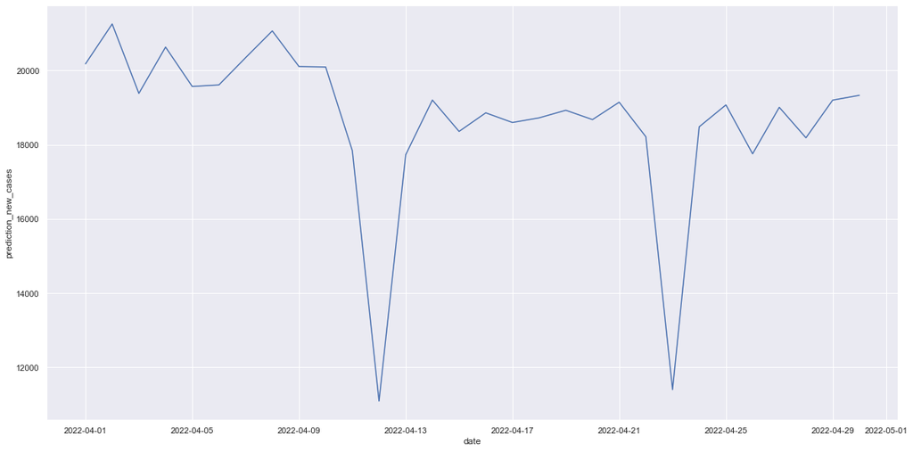

```python
sns.lineplot(data=infection_data_country[-days_predict:], x=infection_data_country[-days_predict:].index, y='prediction_new_cases')
```

В качестве `X` выступает дата, а в качестве `Y` - новые случаи заражения. По графику видно, что в прогнозе есть редкие спады заражения, но сразу после них быстрый подъем (возможно это ошибка модели), который говорит либо о качестве вакцинации, либо о уменьшении заражаемости за счет необъяснимых факторов.

Для того, чтобы наши данные были полными необходимо предсказать уровень опасности предсказанных значений. Для этого воспользуемся функцией `find_danger_level_new_data`, которая вернет нам таблицу с новым признаком - `danger_level`, предсказанный алгоритмом кластеризации - `GaussianMixture`:

```python
infection_data_country = find_danger_level_new_data(infection_data_country)
infection_data_country.head(10)
```

```
Максимальный коэффициент распространения инфекции в кластере 0: 21251.289349365226
Максимальный коэффициент распространения инфекции в кластере 1: 3781.0347616501776
Максимальный коэффициент распространения инфекции в кластере 2: 14844.540058122675
```

| date | prediction_new_cases | location | danger_level |
| --- | --- | --- | --- |
| 2021-12-01 | 8129.171718 | Thailand | не советуем |
| 2021-12-02 | 8081.930766 | Thailand | не советуем |
| 2021-12-03 | 8298.372730 | Thailand | не советуем |
| 2021-12-04 | 8815.522515 | Thailand | не советуем |
| 2021-12-05 | 8489.801979 | Thailand | не советуем |
| 2021-12-06 | 8363.594373 | Thailand | не советуем |
| 2021-12-07 | 8173.333764 | Thailand | не советуем |
| 2021-12-08 | 8041.994576 | Thailand | не советуем |
| 2021-12-09 | 8297.384577 | Thailand | не советуем |
| 2021-12-10 | 8596.559297 | Thailand | не советуем |

## Заключение

В заключении хотелось бы привести основные моменты проекта: